# Correlations, T-tests, ANOVA

```r
source('StatsResourcesConfig.R')
```

This is a quick workshop covering some frequently used statistical tests in psych. The goal is not to cover all the theory and math underlying these tests but to provide an intuition on what question they are intended to address, what their main inputs and outputs are, how they are often visualized and how to run them in R.

To demonstrate most of the methods we’ll use a sample dataset provided in R.

```r
iris
```

| Sepal.Length | Sepal.Width | Petal.Length | Petal.Width | Species |
| --- | --- | --- | --- | --- |
| 5.1 | 3.5 | 1.4 | 0.2 | setosa |
| 4.9 | 3.0 | 1.4 | 0.2 | setosa |
| 4.7 | 3.2 | 1.3 | 0.2 | setosa |
| 4.6 | 3.1 | 1.5 | 0.2 | setosa |
| 5.0 | 3.6 | 1.4 | 0.2 | setosa |
| 5.4 | 3.9 | 1.7 | 0.4 | setosa |
| 4.6 | 3.4 | 1.4 | 0.3 | setosa |
| 5.0 | 3.4 | 1.5 | 0.2 | setosa |
| 4.4 | 2.9 | 1.4 | 0.2 | setosa |
| 4.9 | 3.1 | 1.5 | 0.1 | setosa |

[output cut: 140 more lines]

### Always start with getting a sense of your data!!

```r
str(iris)
```

```
'data.frame':   150 obs. of  5 variables:
 $ Sepal.Length: num  5.1 4.9 4.7 4.6 5 5.4 4.6 5 4.4 4.9 ...
 $ Sepal.Width : num  3.5 3 3.2 3.1 3.6 3.9 3.4 3.4 2.9 3.1 ...
 $ Petal.Length: num  1.4 1.4 1.3 1.5 1.4 1.7 1.4 1.5 1.4 1.5 ...
 $ Petal.Width : num  0.2 0.2 0.2 0.2 0.2 0.4 0.3 0.2 0.2 0.1 ...
 $ Species     : Factor w/ 3 levels "setosa","versicolor",..: 1 1 1 1 1 1 1 1 1 1 ...
```

```r
summary(iris)
```

```
  Sepal.Length    Sepal.Width     Petal.Length    Petal.Width
 Min.   :4.300   Min.   :2.000   Min.   :1.000   Min.   :0.100
 1st Qu.:5.100   1st Qu.:2.800   1st Qu.:1.600   1st Qu.:0.300
 Median :5.800   Median :3.000   Median :4.350   Median :1.300
 Mean   :5.843   Mean   :3.057   Mean   :3.758   Mean   :1.199
 3rd Qu.:6.400   3rd Qu.:3.300   3rd Qu.:5.100   3rd Qu.:1.800
 Max.   :7.900   Max.   :4.400   Max.   :6.900   Max.   :2.500
       Species
 setosa    :50
 versicolor:50
 virginica :50
```

## (Linear) Correlation

(aka Pearson’s correlation)

- Number of variables: 2
- Type of variables: continous
- Output: r value, p value
- Typical plot: scatter plot

```r
cor(iris$Sepal.Length, iris$Sepal.Width)
```

```
[1] -0.1175698
```

```r
cor.test(iris$Sepal.Length, iris$Sepal.Width)
```

```
    Pearson's product-moment correlation

data:  iris$Sepal.Length and iris$Sepal.Width
t = -1.4403, df = 148, p-value = 0.1519
alternative hypothesis: true correlation is not equal to 0
95 percent confidence interval:
 -0.27269325  0.04351158
sample estimates:
       cor
-0.1175698
```

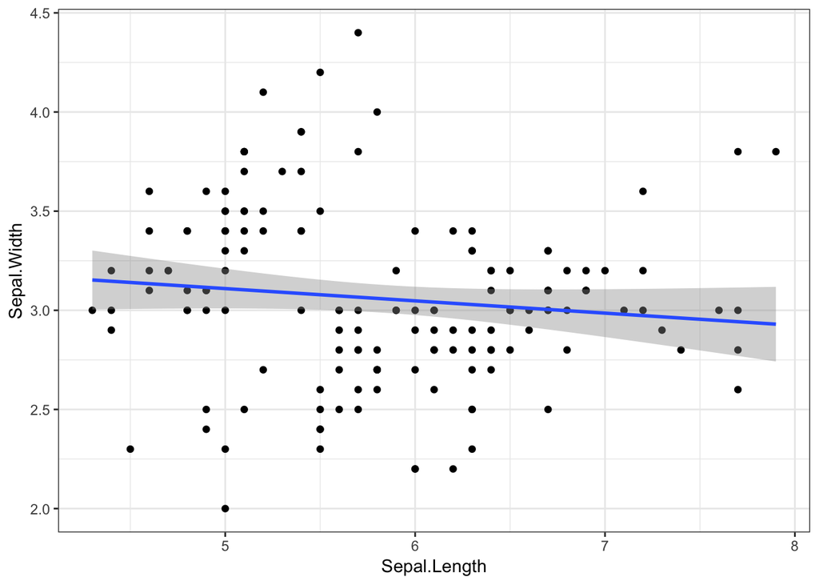

```r
iris %>%
  ggplot(aes(Sepal.Length, Sepal.Width))+
  geom_point()+
  geom_smooth(method="lm")
```

```r
cor.test(iris$Petal.Length, iris$Petal.Width)
```

```
    Pearson's product-moment correlation

data:  iris$Petal.Length and iris$Petal.Width
t = 43.387, df = 148, p-value < 2.2e-16
alternative hypothesis: true correlation is not equal to 0
95 percent confidence interval:
 0.9490525 0.9729853
sample estimates:
      cor
0.9628654
```

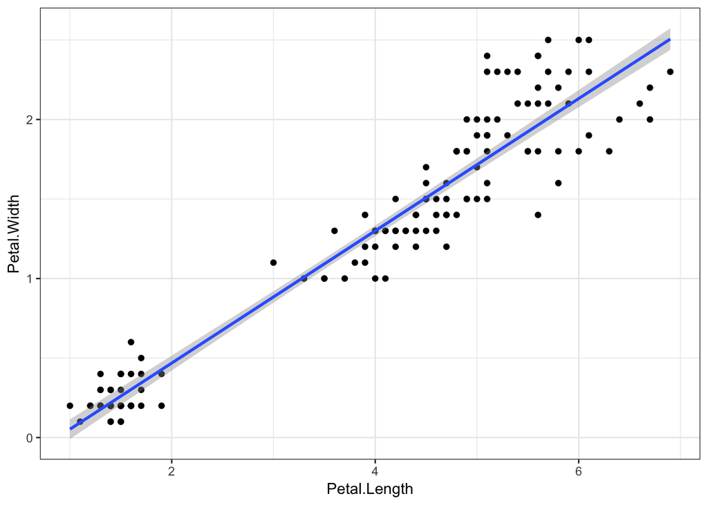

```r
iris %>%
  ggplot(aes(Petal.Length, Petal.Width))+
  geom_point()+
  geom_smooth(method="lm")
```

## T-test

- Number of variables: 2
- Type of variables: 1 continous, 1 categorical with 2 levels
- Output: t value, df, p value
- Typical plot: boxplot, barplot

Important arguments for the `t.test` function: - `alternative`: depends on what hypothesis you are testing (are the distributions different vs. is the mean of one `greater` or `less` than the other) - `paired`: default is `FALSE`; should be set to `TRUE` if the levels refer to different conditions for the same sample

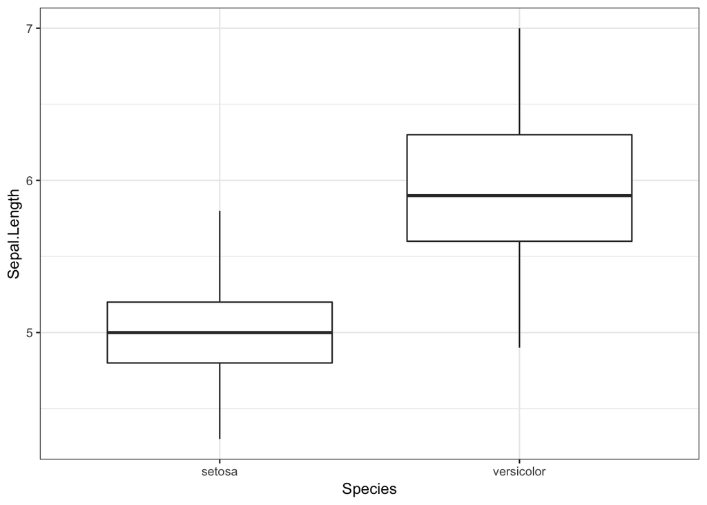

```r
iris %>%
  filter(Species != "virginica") %>%
  ggplot(aes(Species, Sepal.Length))+
  geom_boxplot()
```

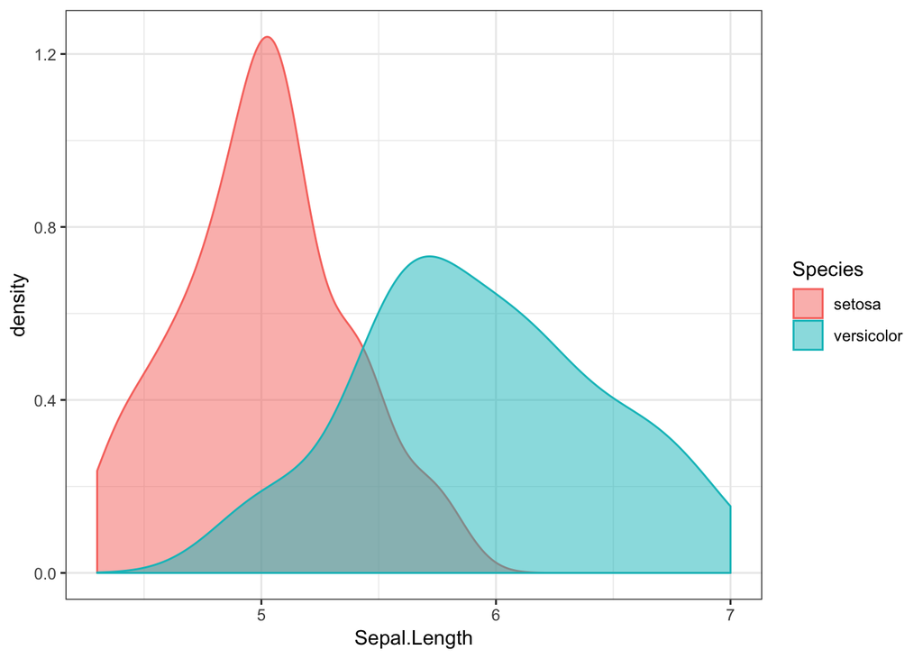

```r
iris %>%
  filter(Species != "virginica") %>%
  ggplot(aes(Sepal.Length, fill=Species, col=Species))+
  geom_density(alpha=0.5)
```

```r
data = iris %>%
  filter(Species != "virginica")
t.test(Sepal.Length ~ Species, data)
```

```
    Welch Two Sample t-test

data:  Sepal.Length by Species
t = -10.521, df = 86.538, p-value < 2.2e-16
alternative hypothesis: true difference in means is not equal to 0
95 percent confidence interval:
 -1.1057074 -0.7542926
sample estimates:
    mean in group setosa mean in group versicolor
                   5.006                    5.936
```

```r
t.test(Sepal.Length ~ Species, data, alternative = "less")
```

```
    Welch Two Sample t-test

data:  Sepal.Length by Species
t = -10.521, df = 86.538, p-value < 2.2e-16
alternative hypothesis: true difference in means is less than 0
95 percent confidence interval:
       -Inf -0.7830302
sample estimates:
    mean in group setosa mean in group versicolor
                   5.006                    5.936
```

```r
t.test(Sepal.Length ~ Species, data, alternative = "less")$p.value < t.test(Sepal.Length ~ Species, data)$p.value
```

```
[1] TRUE
```

```r
t.test(Sepal.Length ~ Species, data, alternative = "greater")
```

```
    Welch Two Sample t-test

data:  Sepal.Length by Species
t = -10.521, df = 86.538, p-value = 1
alternative hypothesis: true difference in means is greater than 0
95 percent confidence interval:
 -1.07697      Inf
sample estimates:
    mean in group setosa mean in group versicolor
                   5.006                    5.936
```

## ANOVA

- Number of variables: >=2
- Type of variables: 1 continous DV, >=1 IV both continuos and categorical
- Output: F value, df, p value
- Typical plot: boxplot, barplot

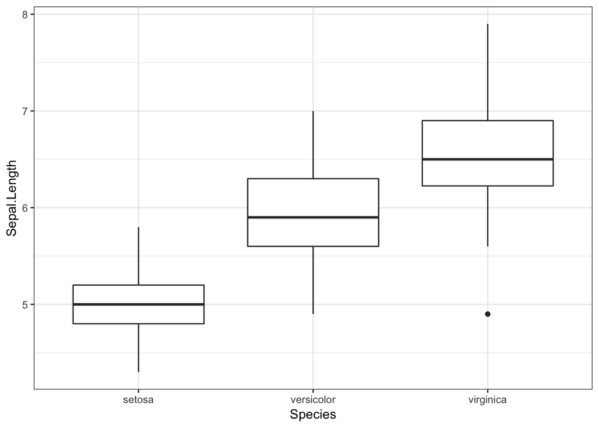

```r
iris %>%
  ggplot(aes(Species, Sepal.Length))+
  geom_boxplot()
```

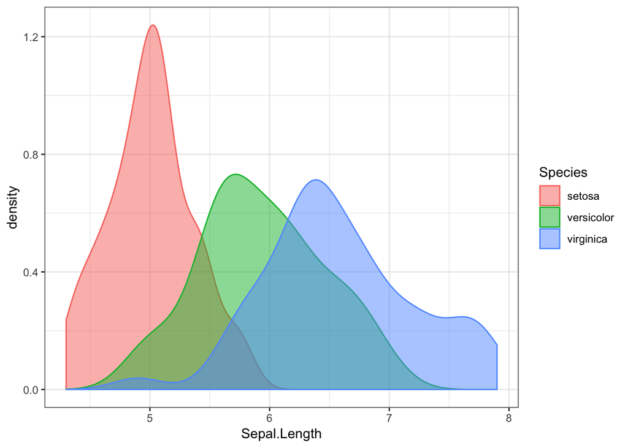

```r
iris %>%
  ggplot(aes(Sepal.Length, fill=Species, col=Species))+
  geom_density(alpha=0.5)
```

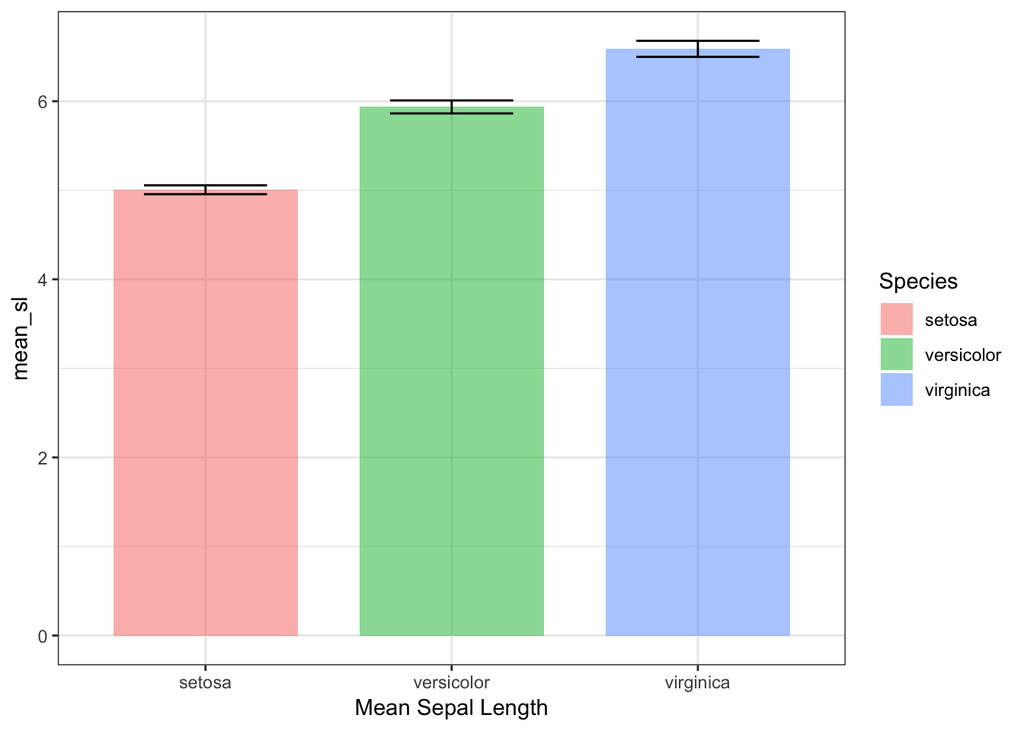

```r
iris %>%
  group_by(Species) %>%
  summarise(mean_sl = mean(Sepal.Length),
            sem_sl = sd(Sepal.Length)/sqrt(n())) %>%
  ggplot(aes(Species, mean_sl, fill=Species))+
  geom_bar(stat = 'identity', alpha = 0.5, width = 0.75)+
  geom_errorbar(aes(ymin = mean_sl-sem_sl, ymax = mean_sl+sem_sl), width = 0.5)+
  xlab("Mean Sepal Length")
```

Only tells us that the means for the groups are different. DOES NOT tell us which is greater than the other. To determine that you’d either run pairwise t-tests or linear regression.

```r
summary(aov(Sepal.Length ~ Species, iris))
```

```
             Df Sum Sq Mean Sq F value Pr(>F)
Species       2  63.21  31.606   119.3 <2e-16 ***
Residuals   147  38.96   0.265
---
Signif. codes:  0 '***' 0.001 '**' 0.01 '*' 0.05 '.' 0.1 ' ' 1
```

Pairwise t-test still DOES NOT tell us which distribution has a higher mean compared to the others. It tells us which two distributions are different than each other.

```r
with(iris, pairwise.t.test(Sepal.Length, Species))
```

```
    Pairwise comparisons using t tests with pooled SD

data:  Sepal.Length and Species

           setosa  versicolor
versicolor 1.8e-15 -
virginica  < 2e-16 2.8e-09

P value adjustment method: holm
```

## Linear regression

- Number of variables: >=2
- Type of variables: 1 continous DV, >=1 IV both continuos and categorical
- Output: (standardized) regression coefficients, t value, df, p value
- Typical plot: scatterplot, boxplot, barplot

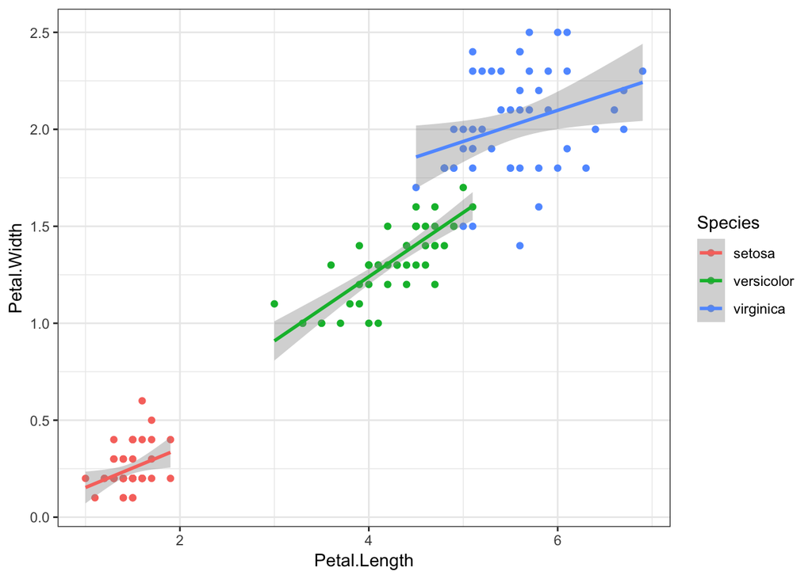

```r
iris %>%
  ggplot(aes(Petal.Length, Petal.Width, color=Species))+
  geom_point()+
  geom_smooth(method = "lm")
```

```r
summary(lm(Petal.Width ~ Petal.Length+Species, iris))
```

```
Call:
lm(formula = Petal.Width ~ Petal.Length + Species, data = iris)

Residuals:
     Min       1Q   Median       3Q      Max
-0.63706 -0.07779 -0.01218  0.09829  0.47814

Coefficients:
                  Estimate Std. Error t value Pr(>|t|)
(Intercept)       -0.09083    0.05639  -1.611    0.109
Petal.Length       0.23039    0.03443   6.691 4.41e-10 ***
Speciesversicolor  0.43537    0.10282   4.234 4.04e-05 ***
Speciesvirginica   0.83771    0.14533   5.764 4.71e-08 ***
---
Signif. codes:  0 '***' 0.001 '**' 0.01 '*' 0.05 '.' 0.1 ' ' 1

Residual standard error: 0.1796 on 146 degrees of freedom
Multiple R-squared:  0.9456,    Adjusted R-squared:  0.9445
F-statistic: 845.5 on 3 and 146 DF,  p-value: < 2.2e-16
```

This is an additive model. It checks for the main effect of `Species` and of `Petal.Length` separately. It tests whether  
1. `Petal.Width` increases significantly as `Petal.Length` increases 2. There are significant differences between the average `Petal.Width` of the other two `Species` compared to setosa.

It DOES NOT check whether `Petal.Width` increases significantly by `Petal.Length` at *different rates* depending on the `Species`. This would be an *interactive* model.

### Model comparison/selection

THIS KIND OF MODEL COMPARISON CAN ONLY BE DONE WITH NESTED MODELS

```r
m1a = lm(Petal.Width ~ Petal.Length, iris)
m1b = lm(Petal.Width ~ Species, iris)
m2 = lm(Petal.Width ~ Petal.Length+Species, iris)
m3 = lm(Petal.Width ~ Petal.Length*Species, iris)
```

```r
anova(m1a, m2, m3)
```

|  | Res.Df | RSS | Df | Sum of Sq | F | Pr(>F) |
| --- | --- | --- | --- | --- | --- | --- |
| 1 | 148 | 6.310096 | NA | NA | NA | NA |
| 2 | 146 | 4.711643 | 2 | 1.5984530 | 25.420346 | 3.508842e-10 |
| 3 | 144 | 4.527421 | 2 | 0.1842221 | 2.929702 | 5.660456e-02 |

```r
anova(m1b, m2, m3)
```

|  | Res.Df | RSS | Df | Sum of Sq | F | Pr(>F) |
| --- | --- | --- | --- | --- | --- | --- |
| 1 | 147 | 6.156600 | NA | NA | NA | NA |
| 2 | 146 | 4.711643 | 1 | 1.4449566 | 45.958557 | 2.883632e-10 |
| 3 | 144 | 4.527421 | 2 | 0.1842221 | 2.929702 | 5.660456e-02 |

Conclusion: `m2`, the additive model, is the best.

## General TIPS

- Always start with getting a good understanding of the structure of your data.
- Not fully comprehensive but [here](http://abacus.bates.edu/~ganderso/biology/resources/stats_flow_chart_v2014.pdf) is an example flowchart of how to choose the correct statistical test depending on your data.
- Whenever you have a question on your data try to imagine what the plot should look like.
- Better yet simulate some data (i.e. create some fake data) and actually make the plot.